# Exploratory Data Analysis Coding Exam

Bonbuttery

2023-10-05

# Data Analysis of the Penguin Dataset using R

Consider that you are an ornithologist stationed in Antartica. You are tasked to catalog the various penguin population in the region. After months of field work, you were able to assemble this dataset Download dataset.

Combine your knowledge on data wrangling and visualization to derive meaningful insights from the data. You are not limited to just a single analysis. You may create multiple visualizations to support your analysis. Cite references whenever necessary. Show all the code and output of the code.

## Load Packages (after installation)

```r
library(ggplot2)
library(RColorBrewer)
```

## Penguin Dataset

### Read Penguin Dataset

```r
# Read csv file
penguin <- read.csv("penguins_size-1.csv")

# Removed All Rows with NA values
penguin1 <- na.omit(penguin)

# Removed Row No. 337 (because of “.” in sex column)
penguin2 <- penguin1[-337,]
```

```r
summary(penguin2)
```

```
##    species             island          bill_length_mm  bill_depth_mm
##  Length:334         Length:334         Min.   :32.10   Min.   :13.10
##  Class :character   Class :character   1st Qu.:39.50   1st Qu.:15.60
##  Mode  :character   Mode  :character   Median :44.50   Median :17.30
##                                        Mean   :43.99   Mean   :17.16
##                                        3rd Qu.:48.58   3rd Qu.:18.70
##                                        Max.   :59.60   Max.   :21.50
##  flipper_length_mm  body_mass_g       sex
##  Min.   :172       Min.   :2700   Length:334
##  1st Qu.:190       1st Qu.:3550   Class :character
##  Median :197       Median :4050   Mode  :character
##  Mean   :201       Mean   :4209
##  3rd Qu.:213       3rd Qu.:4794
##  Max.   :231       Max.   :6300
```

```r
head(penguin2)
```

```
##   species    island bill_length_mm bill_depth_mm flipper_length_mm body_mass_g
## 1  Adelie Torgersen           39.1          18.7               181        3750
## 2  Adelie Torgersen           39.5          17.4               186        3800
## 3  Adelie Torgersen           40.3          18.0               195        3250
## 5  Adelie Torgersen           36.7          19.3               193        3450
## 6  Adelie Torgersen           39.3          20.6               190        3650
## 7  Adelie Torgersen           38.9          17.8               181        3625
##      sex
## 1   MALE
## 2 FEMALE
## 3 FEMALE
## 5 FEMALE
## 6   MALE
## 7 FEMALE
```

```r
tail(penguin2)
```

```
##     species island bill_length_mm bill_depth_mm flipper_length_mm body_mass_g
## 338  Gentoo Biscoe           48.8          16.2               222        6000
## 339  Gentoo Biscoe           47.2          13.7               214        4925
## 341  Gentoo Biscoe           46.8          14.3               215        4850
## 342  Gentoo Biscoe           50.4          15.7               222        5750
## 343  Gentoo Biscoe           45.2          14.8               212        5200
## 344  Gentoo Biscoe           49.9          16.1               213        5400
##        sex
## 338   MALE
## 339 FEMALE
## 341 FEMALE
## 342   MALE
## 343 FEMALE
## 344   MALE
```

## Coding Exam (CE) Plots and Analysis

### CE Plot 1: Body Mass (g) vs Flipper Length (mm) of Penguins in Antarctica

#### Scatter plot

The scatter plot below (Figure 1) shows a clear **linear relationship** between the **body mass (in g)** and **flipper length (in mm)** of the three species of penguins in Antarctica, but the species are not specified. It signifies that as the body mass of the penguins increases, their flipper length increases as well. Another plot below, Figure 2, shows the same relationship but this time specifying the species.

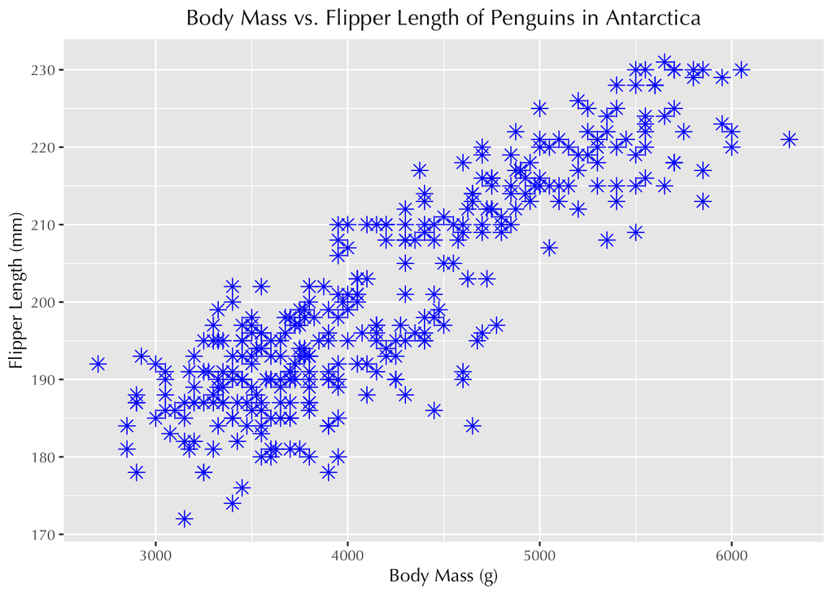

```
                  Figure 1: Scatter Plot of Body Mass vs. Flipper Length of the Penguins in Antarctica
```

```r
plot(ggplot(data = penguin1,
            aes(x = body_mass_g, y = flipper_length_mm, color="Blue")) +
       labs(x = "Body Mass (g)", y = "Flipper Length (mm)") +
       theme(legend.position = "none") +
       ggtitle("Body Mass vs. Flipper Length of Penguins in Antarctica") +
       theme(plot.title = element_text(hjust = 0.5)) +
       theme(text = element_text(family = "Optima")) +
       geom_point(size = 3, shape = 8, color="Blue"))
```

### CE Plot 2: Body Mass (g) vs Flipper Length (mm) of Penguins in Antarctica

#### Scatter plot

The scatter plot, this time, specifies the penguin species that tend to have the highest increase in flipper length when their body mass also increases, which is the **Gentoo** species. This also suggests that this species is the heaviest among the three species. Furthermore, the remaining two species, **Adelie and Chinstrap**, are more or less on the same level.

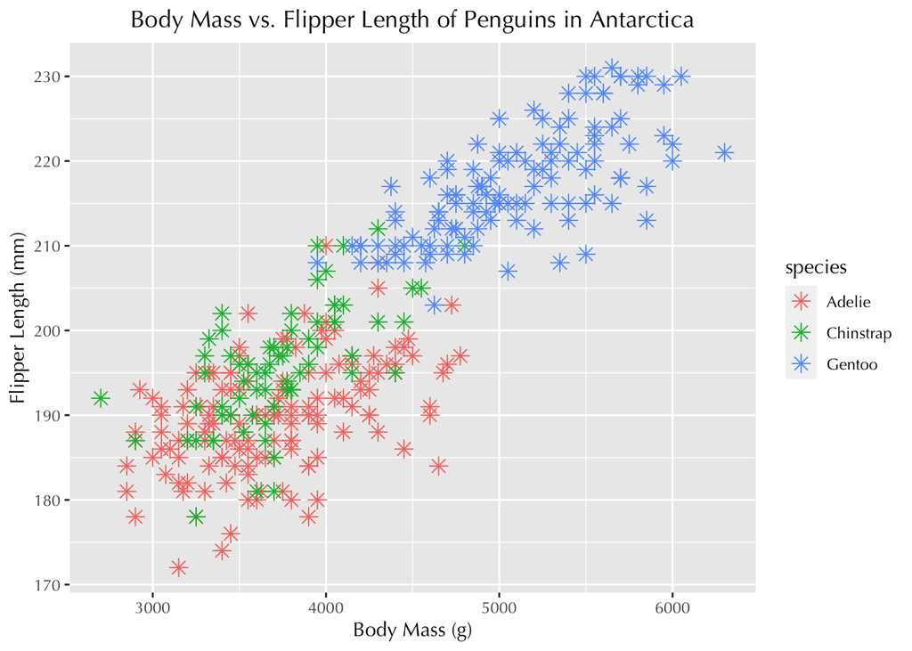

```
    Figure 2:  Scatter Plot of Body Mass vs. Flipper Length of the three Specified Penguin Species in Antarctica
```

```r
ggplot(data = penguin1,
       aes(x = body_mass_g, y = flipper_length_mm, color=species)) +
  labs(x = "Body Mass (g)", y = "Flipper Length (mm)") +
  ggtitle("Body Mass vs. Flipper Length of Penguins in Antarctica") +
  theme(plot.title = element_text(hjust = 0.5)) +
  theme(text = element_text(family = "Optima")) +
  geom_point(size = 3, shape = 8)
```

### CE Plot 3: Body Mass (g) of Penguin Species in Different Islands

#### Bar plot

Figure 3 below shows the comparison of the **Body Mass (in g)** of the different penguin species in Antarctica. From the three species, it is **Gentoo** that has the highest body mass, which is in line with the previous figure’s output, wherein it is also **Gentoo** that has the highest body mass. Furthermore, in this same plot, it is noticeable that in some islands there is an absence of certain penguin species, such as **Chinstrap** in the **islands of Torgersen and Biscoe**, and **Gentoo in Dream and Torgersen islands**. It is only the **Adelie** species that can be **found on all three islands**. Another figure below, Figure 4, confirms our notion as it also shows similar results in terms of the presence and absence of certain species on a particular island.

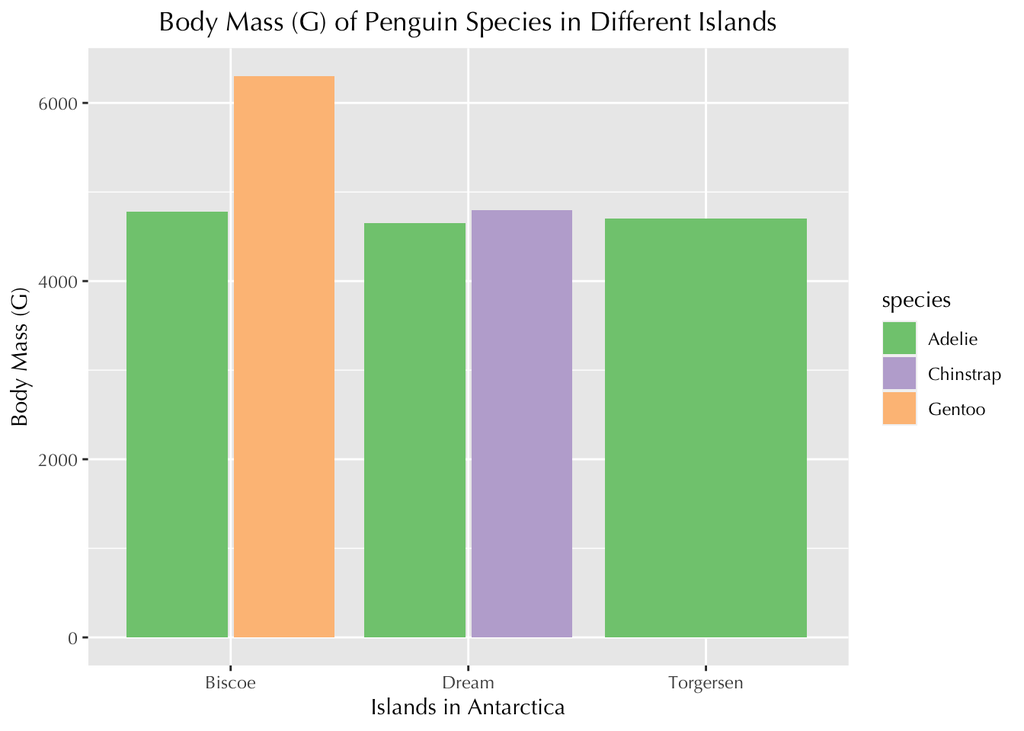

```
    Figure 3:  Grouped Bar Plot of Body Masses of the 3 different Penguin Species in Different Antarctic Islands
```

```r
ggplot(data = penguin2,
       aes(x = island, y = body_mass_g, fill = species)) +
  geom_bar(position=position_dodge(0.9), width=0.85, stat="identity") +
  theme(text = element_text(family = "Optima")) +
  ggtitle("Body Mass (G) of Penguin Species in Different Islands") +
  theme(plot.title = element_text(hjust = 0.5)) + scale_fill_brewer(palette="Accent") +
  labs(x="Islands in Antarctica", y="Body Mass (G)")
```

### CE Plot 4: Frequency of Penguin Species in Different Antarctic Islands

#### Bar plot

As previously introduced in Figure 3, the bar plot below shows the counts of sampled penguins in Antarctica, and it confirms the previous idea that other penguin species are not present on other islands. Additionally, on the **island of Biscoe**, where there were *no recorded Chinstrap species*, **Gentoo** species dominate the island with the highest individual count. On **Dream Island**, it is the other way around, with *no Gentoo species*, and their number is *also higher than* the **Adelie**.

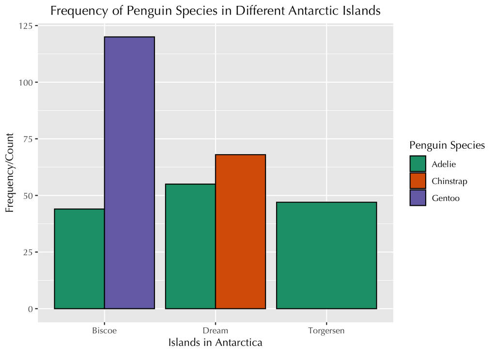

```
    Figure 4:  Grouped Bar Plot of the Frequency of Penguin Species in Different Antarctic Islands
```

```r
ggplot(data = penguin2,
       aes(x=island, fill=species)) +
  geom_bar(position = "dodge", color="black") +
  ggtitle("Frequency of Penguin Species in Different Antarctic Islands") +
  theme(plot.title = element_text(hjust = 0.5)) +
  scale_fill_brewer(palette="Dark2", name = "Penguin Species") +
  labs(x="Islands in Antarctica", y="Frequency/Count") +
  theme(text = element_text(family = "Optima"))
```

### CE Plot 5: Comparison of Bill Length of Penguin Species in Antarctica

#### Box plot

In this figure, Figure 5, the **bill lengths** of the three penguin species are compared using a boxplot. It is found that the **Chinstrap** species possesses the *highest mean bill length* among the three species, **Adelie** with the *lowest mean*, and **Gentoo** just closely *behind Chinstrap*. However, to confirm our visual assumptions, more specific statistical analysis is necessary.

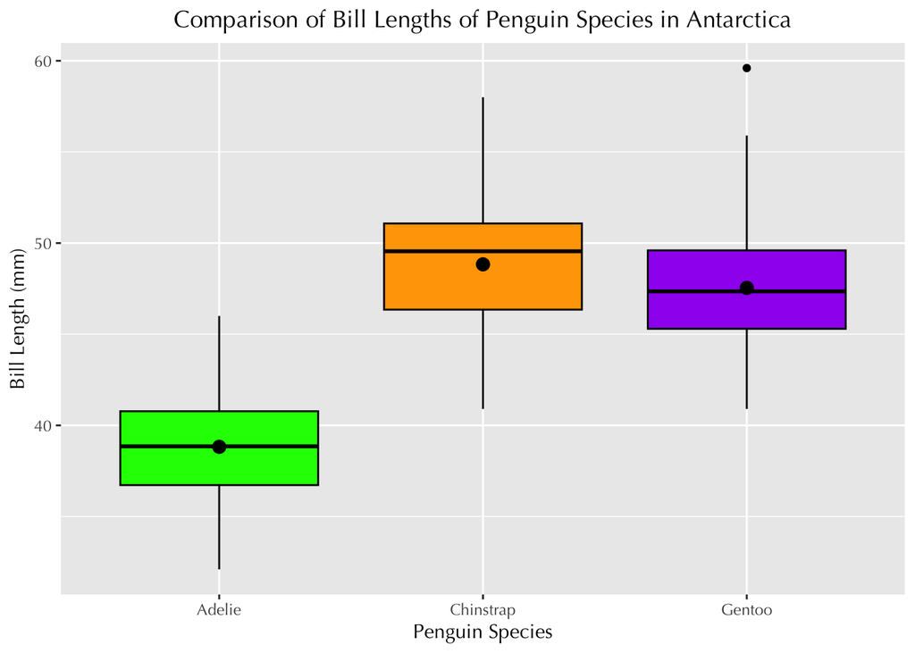

```
                Figure 5: Boxplot Comparing the Bill Lengths of the Three Penguin Species in Antarctic
```

```r
ggplot(data = penguin2,
       aes(x = species, y=bill_length_mm)) +
  labs(x = "Penguin Species", y = "Bill Length (mm)") +
  theme(legend.position = "none") +
  ggtitle("Comparison of Bill Lengths of Penguin Species in Antarctica") +
  theme(plot.title = element_text(hjust = 0.5)) +
  theme(text = element_text(family = "Optima")) +
  geom_boxplot(col="Black", fill=c("Green", "Orange", "Purple")) +
  stat_summary(fun=mean, geom='point', shape=19, size=3)
```

##### For the purpose of improving and doing a more thorough research, this data analysis of the Penguin dataset is available for revisions and comments. You are welcome to modify, analyze, and utilize these visual analyses however you like. Simply remember to give credit :)))

# THE END :)))